# Question 1B: Spatial Regression (20 marks)

Shared with you are two files:

1. “italy.shapefile”, a shapefile consisting geometries of the Italian regions along with the following attributes,
1. REGION: name of the Italian region
2. VAR_UNEMP: variation in unemployment
3. VAR_RGDP: variation in real GDP
2. “it.nb”, a GAL file to generate queen contiguity neighbours of the Italian regions.

```r
library(sf); library(spdep); library(spatialreg)
```

Answer the following questions:

1. (5 marks) Load the italy.shapefile and regress VAR_UNEMP on VAR_RGDP. (The inverse relationship between the variation in unemployment and variation in real GDP is known as Okun’s law in the economics literature.)

```r
(italy = st_read("italy_okun.shp"))
```

```
## Simple feature collection with 20 features and 3 fields
## Geometry type: MULTIPOLYGON
## Dimension:     XY
## Bounding box:  xmin: 4055456 ymin: 1422800 xmax: 5047056 ymax: 2665352
## Projected CRS: ETRS89-extended / LAEA Europe
## First 10 features:
##                   REGION VAR_UNEMP VAR_RGDP                       geometry
## 1               Sardinia       9.9      0.7 MULTIPOLYGON (((4299705 195...
## 2                 Veneto       3.3      1.8 MULTIPOLYGON (((4530306 261...
## 3  Friuli Venezia Giulia       3.4      1.9 MULTIPOLYGON (((4600801 252...
## 4         Emilia Romagna       2.9      2.0 MULTIPOLYGON (((4285438 244...
## 5                Tuscany       4.3      1.1 MULTIPOLYGON (((4358646 234...
## 6                 Umbira       4.6      2.3 MULTIPOLYGON (((4545500 226...
## 7                 Marche       4.2      1.8 MULTIPOLYGON (((4542187 232...
## 8                 Latium       6.4      2.0 MULTIPOLYGON (((4526488 214...
## 9               Calabria      11.3      0.2 MULTIPOLYGON (((4927897 184...
## 10                Sicily      13.0      0.1 MULTIPOLYGON (((4787072 165...
```

```r
# OLS
OLS = lm(VAR_UNEMP~VAR_RGDP, data=italy)
```

1. Show the summary of the regression.

```r
summary(OLS)
```

```
##
## Call:
## lm(formula = VAR_UNEMP ~ VAR_RGDP, data = italy)
##
## Residuals:
##     Min      1Q  Median      3Q     Max
## -3.4449 -1.7419 -0.3307  1.4994  6.2162
##
## Coefficients:
##             Estimate Std. Error t value Pr(>|t|)
## (Intercept)   10.971      1.283   8.551 9.38e-08 ***
## VAR_RGDP      -3.326      0.835  -3.984 0.000871 ***
## ---
## Signif. codes:  0 '***' 0.001 '**' 0.01 '*' 0.05 '.' 0.1 ' ' 1
##
## Residual standard error: 2.562 on 18 degrees of freedom
## Multiple R-squared:  0.4686, Adjusted R-squared:  0.4391
## F-statistic: 15.87 on 1 and 18 DF,  p-value: 0.0008705
```

2. Give a scatterplot of the variables along with the fitted line.

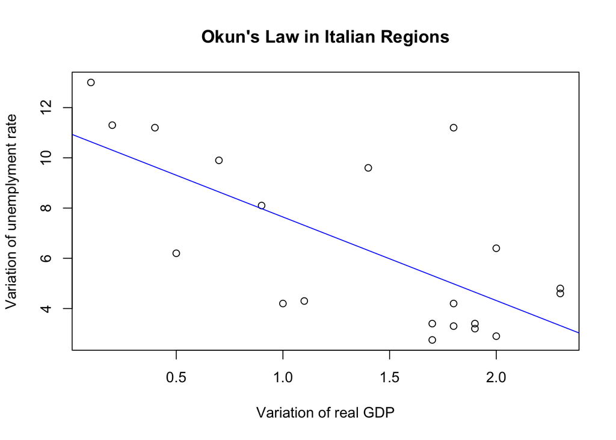

```r
plot(italy$VAR_RGDP,italy$VAR_UNEMP, main="Okun's Law in Italian Regions",
     ylab="Variation of unemplyment rate", xlab="Variation of real GDP")
abline(OLS,col="Blue")
```

3. Check for homoskedasticity and normality of the regression errors.

```r
lmtest::bptest(OLS) # Do not reject H0: homoskedasticity
```

```
##
##  studentized Breusch-Pagan test
##
## data:  OLS
## BP = 0.022502, df = 1, p-value = 0.8808
```

```r
tseries::jarque.bera.test(OLS$residuals) # Do not reject H0: normal
```

```
##
##  Jarque Bera Test
##
## data:  OLS$residuals
## X-squared = 1.2331, df = 2, p-value = 0.5398
```

2. (5 marks) Load the GAL file and create a neighbourhood connectivity plot on a map of Italy. Conduct Moran’s tests on the OLS residuals and the model variables to check whether spatial spill-over effects need to be considered in the model.

```r
# nb
# (it_nb = poly2nb(italy))
(it_nb = read.gal("italy.gal"))
```

```
## Neighbour list object:
## Number of regions: 20
## Number of nonzero links: 65
## Percentage nonzero weights: 16.25
## Average number of links: 3.25
## Non-symmetric neighbours list
```

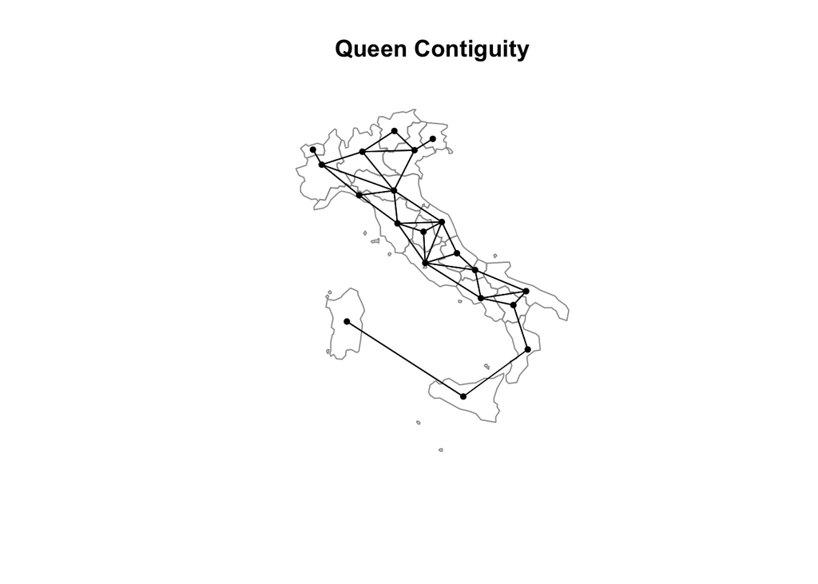

```r
it_coords = st_point_on_surface(st_geometry(italy))
plot(st_geometry(italy), border="grey60",  main="Queen Contiguity")
plot(it_nb, it_coords, pch=19, cex=0.6, add=T)
```

```r
(it_lw = nb2listw(it_nb))
```

```
## Characteristics of weights list object:
## Neighbour list object:
## Number of regions: 20
## Number of nonzero links: 65
## Percentage nonzero weights: 16.25
## Average number of links: 3.25
## Non-symmetric neighbours list
##
## Weights style: W
## Weights constants summary:
##    n  nn S0       S1       S2
## W 20 400 20 14.87722 84.58167
```

```r
# Tests to detect spatial autocorrelation

# in OLS residuals
lm.morantest(OLS, it_lw) # Reject null of CSR
```

```
##
##  Global Moran I for regression residuals
##
## data:
## model: lm(formula = VAR_UNEMP ~ VAR_RGDP, data = italy)
## weights: it_lw
##
## Moran I statistic standard deviate = 2.8459, p-value = 0.002214
## alternative hypothesis: greater
## sample estimates:
## Observed Moran I      Expectation         Variance
##       0.41745849      -0.06686060       0.02896088
```

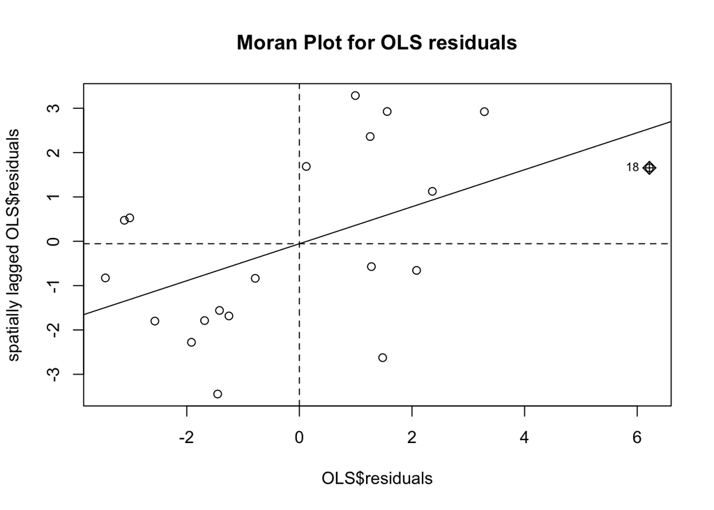

```r
moran.plot(OLS$residuals, it_lw, main="Moran Plot for OLS residuals")
```

```r
# in other variables
moran.test(italy$VAR_UNEMP, it_lw) # Reject null of CSR
```

```
##
##  Moran I test under randomisation
##
## data:  italy$VAR_UNEMP
## weights: it_lw
##
## Moran I statistic standard deviate = 4.9444, p-value = 3.819e-07
## alternative hypothesis: greater
## sample estimates:
## Moran I statistic       Expectation          Variance
##        0.84790473       -0.05263158        0.03317208
```

```r
moran.test(italy$VAR_RGDP, it_lw) # Do not reject the null of CSR
```

```
##
##  Moran I test under randomisation
##
## data:  italy$VAR_RGDP
## weights: it_lw
##
## Moran I statistic standard deviate = 1.4078, p-value = 0.07959
## alternative hypothesis: greater
## sample estimates:
## Moran I statistic       Expectation          Variance
##        0.20349084       -0.05263158        0.03309874
```

3. (10 marks) Run the usual spatial regressions and conduct appropriate tests to identify the most suitable spatial regression model.

```r
unemp_SAR = spautolm(formula = VAR_UNEMP ~ 1, data=italy, listw=it_lw)
unemp_SLM = lagsarlm(formula = VAR_UNEMP ~ VAR_RGDP, data=italy, listw=it_lw)
unemp_SEM = errorsarlm(formula = VAR_UNEMP ~ VAR_RGDP, data=italy, listw=it_lw)
unemp_SARAR = sacsarlm(formula = VAR_UNEMP ~ VAR_RGDP, data=italy, listw=it_lw)

# tests
lm.LMtests(OLS, listw=it_lw, test="all") # possible SLM
```

```
## Please update scripts to use lm.RStests in place of lm.LMtests
```

```
##
##  Rao's score (a.k.a Lagrange multiplier) diagnostics for spatial
##  dependence
##
## data:
## model: lm(formula = VAR_UNEMP ~ VAR_RGDP, data = italy)
## test weights: listw
##
## RSerr = 4.6856, df = 1, p-value = 0.03042
##
##
##  Rao's score (a.k.a Lagrange multiplier) diagnostics for spatial
##  dependence
##
## data:
## model: lm(formula = VAR_UNEMP ~ VAR_RGDP, data = italy)
## test weights: listw
##
## RSlag = 12.874, df = 1, p-value = 0.0003332
##
##
##  Rao's score (a.k.a Lagrange multiplier) diagnostics for spatial
##  dependence
##
## data:
## model: lm(formula = VAR_UNEMP ~ VAR_RGDP, data = italy)
## test weights: listw
##
## adjRSerr = 1.3379, df = 1, p-value = 0.2474
##
##
##  Rao's score (a.k.a Lagrange multiplier) diagnostics for spatial
##  dependence
##
## data:
## model: lm(formula = VAR_UNEMP ~ VAR_RGDP, data = italy)
## test weights: listw
##
## adjRSlag = 9.5259, df = 1, p-value = 0.002026
##
##
##  Rao's score (a.k.a Lagrange multiplier) diagnostics for spatial
##  dependence
##
## data:
## model: lm(formula = VAR_UNEMP ~ VAR_RGDP, data = italy)
## test weights: listw
##
## SARMA = 14.212, df = 2, p-value = 0.0008204
```

```r
LR1.Sarlm(unemp_SLM) # Reject H0:OLS
```

```
##
##  Likelihood Ratio diagnostics for spatial dependence
##
## data:
## Likelihood ratio = 22.068, df = 1, p-value = 2.632e-06
## sample estimates:
## Log likelihood of spatial lag model         Log likelihood of OLS fit y
##                           -35.10964                           -46.14346
```

```r
LR1.Sarlm(unemp_SARAR) # Reject H0:OLS
```

```
##
##  Likelihood Ratio diagnostics for spatial dependence
##
## data:
## Likelihood ratio = 25.947, df = 2, p-value = 2.321e-06
## sample estimates:
## Log likelihood of spatial lag model         Log likelihood of OLS fit y
##                           -33.17007                           -46.14346
```

```r
LR1.Sarlm(unemp_SEM) # Reject H0:OLS
```

```
##
##  Likelihood Ratio diagnostics for spatial dependence
##
## data:
## Likelihood ratio = 19.437, df = 1, p-value = 1.039e-05
## sample estimates:
## Log likelihood of spatial error model           Log likelihood of OLS fit y
##                             -36.42473                             -46.14346
```

```r
LR.Sarlm(unemp_SEM,unemp_SARAR) # Reject H0
```

```
##
##  Likelihood ratio for spatial linear models
##
## data:
## Likelihood ratio = -6.5093, df = 1, p-value = 0.01073
## sample estimates:
##   Log likelihood of unemp_SEM Log likelihood of unemp_SARAR
##                     -36.42473                     -33.17007
```

```r
LR.Sarlm(unemp_SLM,unemp_SARAR) # Reject H0
```

```
##
##  Likelihood ratio for spatial linear models
##
## data:
## Likelihood ratio = -3.8791, df = 1, p-value = 0.04889
## sample estimates:
##   Log likelihood of unemp_SLM Log likelihood of unemp_SARAR
##                     -35.10964                     -33.17007
```

```r
LR.Sarlm(unemp_SAR,unemp_SLM) # Reject H0
```

```
##
##  Likelihood ratio for spatial linear models
##
## data:
## Likelihood ratio = -6.6515, df = 1, p-value = 0.009907
## sample estimates:
## Log likelihood of unemp_SAR Log likelihood of unemp_SLM
##                   -38.43537                   -35.10964
```

```r
# Overall SARAR model is better suited.
```